# Problem Set 1 — POLS601

Zhengyu Xiao

2025-10-05

# Simulation

```r
set.seed(123)
library(dplyr)
library(tidyverse)
```

```r
library(ggplot2)
```

## Randomly samples n observations from a population with some distribution of traits

```r
N <- 100000
traits <- c("A","B","C","D")
p_true  <- c(0.20, 0.10, 0.30, 0.40)
```

## Create population with traits following true probabilities

```r
population <- data.frame(
  id <- 1:N,
  trait <- sample(traits, size = N, replace = TRUE, prob = p_true)
)
```

## Function to run n times of simulation

```r
simulation <- function(n){
  # sample n observations from population
  sample_data <- population %>% sample_n(n)
  # randomly assign treatment with equal probability
  sample_data$treatment <- rbinom(n, size = 1, prob = 0.5)

  #compute trait proportions for entire sample
  sample_data$trait <- factor(sample_data$trait, levels = traits)
  prop_all <- prop.table(table(sample_data$trait))
  prop_treatment <- prop.table(table(sample_data$trait[sample_data$treatment == 1]))
  prop_control <- prop.table(table(sample_data$trait[sample_data$treatment == 0]))

  #Tidy Data
  data.frame(
    group = rep(c("Sample", "Treatment", "Control"), each = length(traits)),
    trait = rep(traits, 3),
    proportion = c(prop_all, prop_treatment, prop_all),
    n=n
  )
}
```

## Run simulation for increasing sample sizes and plot

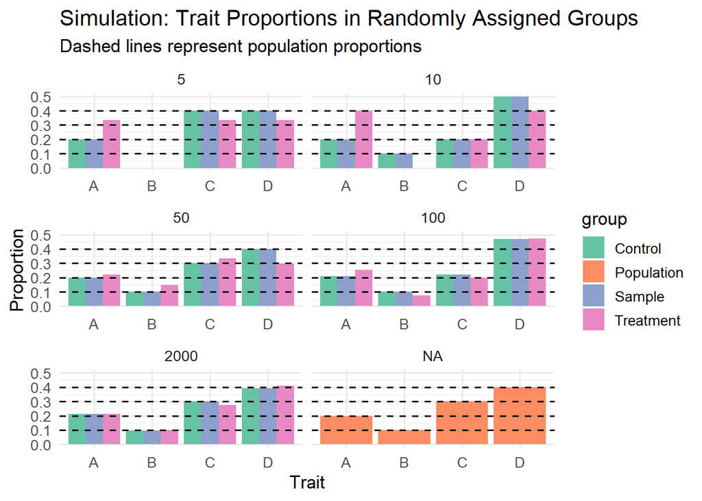

```r
sample_sizes <- c(5, 10, 50, 100, 2000)
result_list <- lapply(sample_sizes, simulation)
sim_results <- rbind(result_list[[1]], result_list[[2]], result_list[[3]], result_list[[4]], result_list[[5]])

# Add population proportions for comparison
pop_df <- data.frame(
  group = "Population",
  trait = traits,
  proportion = p_true,
  n = NA
)

# Combine results
plot_data <- rbind(sim_results, pop_df)

# Plot
ggplot(plot_data, aes(x = trait, y = proportion, fill = group)) +
  geom_bar(stat = "identity", position = "dodge") +
  facet_wrap(~ n, ncol = 2, scales = "free_x") +
  geom_hline(yintercept = p_true, color = "black", linetype = "dashed") +
  labs(
    title = "Simulation: Trait Proportions in Randomly Assigned Groups",
    subtitle = "Dashed lines represent population proportions",
    x = "Trait",
    y = "Proportion"
  ) +
  theme_minimal(base_size = 13) +
  scale_fill_brewer(palette = "Set2")
```

## So from the simulation it is clear that as n increases, the distribution of traits in the sample, treatment and control groups have similar proportions to the distribution in the population.

# Data Analysis

```r
voting <- read.csv("voting.csv")

class(voting$message)
```

```
## [1] "character"
```

```r
class(voting$voted)
```

```
## [1] "integer"
```

```r
class(voting$birth)
```

```
## [1] "integer"
```

### Treatment is the social pressure message, it is a discrete variable, the data type is character/string

## Create a new treatment variable in your data frame that is a binary version of the existing treatment variable. Your new variable should equal 1 if the observation was treated, and 0 otherwise.

```r
voting$treatment <- ifelse (voting$message == "yes", 1, 0)
```

## Compute the average outcome for the treatment group and the average outcome for the control group. Interpret the results by writing 1-2 sentences about what these numbers mean substantively.

```r
avg_outcome <- voting %>%
  group_by (treatment) %>%
  summarise (avg_outcome = mean (voted, na.rm = TRUE))

avg_outcome_treatment <- avg_outcome$avg_outcome[avg_outcome$treatment == 1]
avg_outcome_control <- avg_outcome$avg_outcome[avg_outcome$treatment == 0]

avg_outcome_treatment
```

```
## [1] 0.3779482
```

```r
avg_outcome_control
```

```
## [1] 0.2966383
```

### Interpret: The average turnout in the treatment group, who received the social pressure message, was 37.8%, compared to 29.7% in the control group. This indicates that exposure to the social pressure mailing substantially increased the likelihood of voting, raising turnout by about 8 percentage points.

## What is the average birth year for the treatment and control groups?

```r
# Use brackets to subset the data frame and create two new data frames, one for the treatment group and one for the control group.
treatment_data <- voting[voting$treatment == 1, ]
control_data <- voting[voting$treatment == 0, ]

avg_birth_treatment <- mean(treatment_data$birth)
avg_birth_control <- mean(control_data$birth)
avg_birth_treatment
```

```
## [1] 1956.147
```

```r
avg_birth_control
```

```
## [1] 1956.186
```

### The average birth year for treatment group is 1956.147, for control group is 1956.186

## What is the estimated average causal effect for this experiment? Provide the calculated average effect and a substantive interpretation.

```r
estimated_effect <- avg_outcome_treatment - avg_outcome_control
estimated_effect
```

```
## [1] 0.08130991
```

### Interpret: exposure to the social pressure mailing substantially increased the likelihood of voting, raising turnout by about 8 percentage points

## Suppose we wanted to claim that the estimated causal effect is an estimated effect for the entire U.S. population. What assumption would need to hold for us to make this claim?

### To treat the estimated causal effect from this experiment as the causal effect for the entire U.S. voting-eligible population, we need an external validity assumption. The sample of voters included in the study must be representative of the broader electorate in ways that matter for how the treatment operates, or else we must assume that the effect of receiving a social pressure mailing is constant across different subgroups of voters. In other words, the process by which these voters were sampled should not bias the relationship between the mailing and the decision to vote. In addition, the standard causal assumptions of randomized experiments must hold. The Stable Unit Treatment Value Assumption requires that one person’s turnout decision is not affected by whether others around them received a mailing, and that all treated voters were exposed to the same type of social pressure message. Finally, random assignment must be valid: each voter in the study must have had an equal chance of being assigned to the mailing or no-mailing condition, and this assignment must not be correlated with their underlying propensity to vote.